# R Markdown Lecture

Package: genstats  
Author: Jeff Leek  
Compilation date: 2015-08-21

## Setting some global options

These chunks of code set up some global options to make the markdown pretty.

```r
BiocStyle::markdown()
```

```r
## see ch. 10 Hooks of Xie's knitr book
knit_hooks$set(setPch = function(before, options, envir) {
  if(before) par(pch = 19)
})
opts_chunk$set(setPch = TRUE)
```

## Compiling documents

1. Try compiling this document using the “Knit HTML” button. What files are produced?
2. Edit the output to be “pdf_document” and recompile. What files are produced?
3. Edit the output to be “word_document” and recompile. What files are produced?

## Naming code chunks

The label “chunk1” tells you which part of the code was running in case you have errors. If you compile this document you'll see it under the “R markdown” window on R studio.

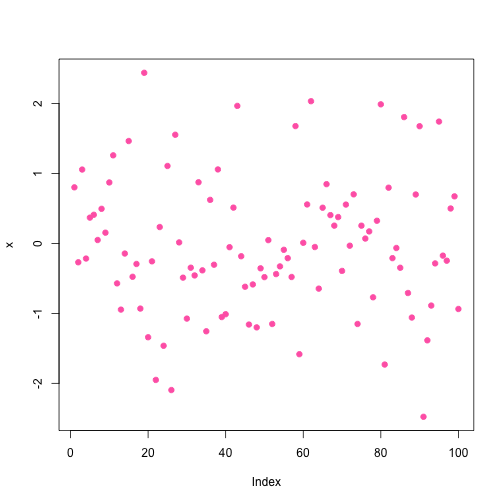

```r
x = rnorm(100)
plot(x,col=3)
```

# This is a primary header.

## This a secondary header

### This is a tertiary header

## Lists

You can create bulleted and numbered lists in the following way.

- Bullet item 1
- Bullet item 2
- Bullet item 3
1. Numbered item 1
2. Numbered item 2
3. Numbered item 3

## Figures

The main arguments you might want to change are centering and figure height.

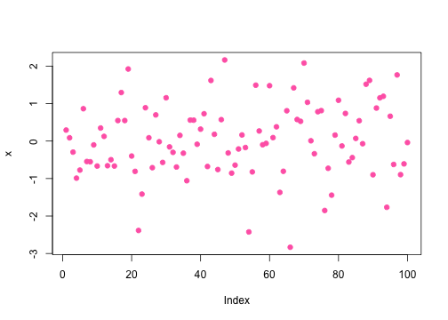

```r
x = rnorm(100)
plot(x,col=3,pch=19)
```

## Other chunk arguments

Add a chunk option of `echo=FALSE` to hide the code.

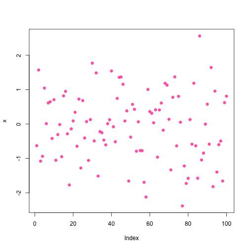

Setting `cache=TRUE` makes it so that the code won't take as long to compile the second time. To see this, uncomment the code below and then run the document twice.

```r
#Sys.sleep(10)
```

## Session information

It is very useful to record the session information when performing analyses so you can collaborate with yourself in the future.

[session information not shown]

```
##  setting  value
##  version  R version 3.2.1 (2015-06-18)
##  system   x86_64, darwin10.8.0
##  ui       RStudio (0.99.447)
##  language (EN)
##  collate  en_US.UTF-8
##  tz       America/New_York
```

```
## Packages ------------------------------------------------------------------
```

```
##  package        * version date
##  AnnotationDbi  * 1.30.1  2015-04-26
##  assertthat       0.1     2013-12-06
##  Biobase        * 2.28.0  2015-04-17
##  BiocGenerics   * 0.14.0  2015-04-17
##  BiocStyle      * 1.6.0   2015-04-17
##  codetools        0.2-14  2015-07-15
##  curl             0.9.2   2015-08-08
##  DBI            * 0.3.1   2014-09-24
##  devtools       * 1.8.0   2015-05-09
##  digest           0.6.8   2014-12-31
##  dplyr          * 0.4.2   2015-06-16
##  evaluate         0.7.2   2015-08-13
##  formatR          1.2     2015-04-21
##  GenomeInfoDb   * 1.4.2   2015-08-15
##  git2r            0.11.0  2015-08-12
##  htmltools        0.2.6   2014-09-08
##  IRanges        * 2.2.7   2015-08-09
##  knitr          * 1.11    2015-08-14
##  lazyeval         0.1.10  2015-01-02
##  magrittr         1.5     2014-11-22
##  markdown         0.7.7   2015-04-22
##  memoise          0.2.1   2014-04-22
##  mime             0.3     2015-03-29
##  org.Hs.eg.db   * 3.1.2   2015-07-17
##  R6               2.1.1   2015-08-19
##  Rcpp             0.12.0  2015-07-25
##  rmarkdown        0.7     2015-06-13
##  RSkittleBrewer * 1.1     2015-07-09
##  RSQLite        * 1.0.0   2014-10-25
##  rstudioapi       0.3.1   2015-04-07
##  rversions        1.0.2   2015-07-13
##  S4Vectors      * 0.6.3   2015-07-31
##  stringi          0.5-5   2015-06-29
##  stringr          1.0.0   2015-04-30
##  xml2             0.1.1   2015-06-02
##  yaml             2.1.13  2014-06-12
##  source
##  Bioconductor
##  CRAN (R 3.2.0)
```

[output cut: 19 more lines]

```
##  CRAN (R 3.2.0)
##  CRAN (R 3.2.0)
##  Bioconductor
##  CRAN (R 3.2.1)
##  CRAN (R 3.2.1)
##  CRAN (R 3.2.1)
##  Github (alyssafrazee/RSkittleBrewer@0a96a20)
##  CRAN (R 3.2.0)
##  CRAN (R 3.2.0)
##  CRAN (R 3.2.1)
##  Bioconductor
##  CRAN (R 3.2.1)
##  CRAN (R 3.2.0)
##  CRAN (R 3.2.1)
##  CRAN (R 3.2.0)
```